# Part 2

2026-08-18

## R Markdown

```r
library(Mcomp)
```

```r
library(forecast)
library(ggplot2)
library(fpp2)
library(tseries)
library(smooth)
library(dplyr)
```

## SET UP

```r
tsis <- 1001:1100
tsn <- length(tsis)
Methods <- c(
  "ETS",
  "ARIMA",
  "Combined",
  "Naive",
  "SeasonalNaive"
)

#MASE errors for each series and each model - 100x5 model (100 series for 3 proposed models and 2 benchmark models)
MASE <- array(
  NA,
  c(tsn, length(Methods))
)
colnames(MASE) <- Methods

sMAPE <- array(
  NA,
  c(tsn, length(Methods))
)
colnames(sMAPE) <- Methods
```

## Data Description

```r
data_summary <- array(
  NA,
  c(tsn, 7)
)

colnames(data_summary) <- c(
  "M3_ID",
  "Series_Name",
  "Period",
  "Type",
  "Train_Length",
  "Test_Length",
  "Frequency"
)

for (tsi in tsis) {

  y <- M3[[tsi]]$x
  yout <- M3[[tsi]]$xx

  data_summary[tsi - 1000, ] <- c(
    tsi,
    M3[[tsi]]$sn,
    M3[[tsi]]$period,
    M3[[tsi]]$type,
    length(y),
    length(yout),
    frequency(y)
  )

}

data_summary<-as.data.frame(data_summary)
print(data_summary)
```

```
##     M3_ID Series_Name    Period  Type Train_Length Test_Length Frequency
## 1    1001       N1001 QUARTERLY MACRO           44           8         4
## 2    1002       N1002 QUARTERLY MACRO           44           8         4
## 3    1003       N1003 QUARTERLY MACRO           44           8         4
## 4    1004       N1004 QUARTERLY MACRO           44           8         4
## 5    1005       N1005 QUARTERLY MACRO           44           8         4
## 6    1006       N1006 QUARTERLY MACRO           44           8         4
## 7    1007       N1007 QUARTERLY MACRO           44           8         4
## 8    1008       N1008 QUARTERLY MACRO           44           8         4
## 9    1009       N1009 QUARTERLY MACRO           44           8         4
## 10   1010       N1010 QUARTERLY MACRO           44           8         4
## 11   1011       N1011 QUARTERLY MACRO           16           8         4
## 12   1012       N1012 QUARTERLY MACRO           44           8         4
## 13   1013       N1013 QUARTERLY MACRO           44           8         4
## 14   1014       N1014 QUARTERLY MACRO           44           8         4
```

[output cut: 86 more lines]

Although the series share the same quarterly frequency, they do not all contain the same number of training observations. Most series contain 44 observations in the training sample, whereas some have shorter histories, such as series N1011, which contains only 16 observations. This difference is relevant because models fitted to shorter series have less historical information available for estimating trend, seasonality and other forecasting patterns.

```r
train_lengths<-data.frame(
  M3_ID = sapply(tsis, function(i) M3[[i]]$sn),
  Train_Length = sapply(tsis, function(i) M3[[i]]$n)
)

count(train_lengths, Train_Length)
```

```
##   Train_Length  n
## 1           16  1
## 2           26  5
## 3           44 94
```

```r
test_lengths <- data.frame(
  M3_ID = tsis,
  Test_Length = sapply(
    tsis,
    function(i) length(M3[[i]]$xx)
  )
)

count(test_lengths, Test_Length)
```

```
##   Test_Length   n
## 1           8 100
```

Most series have a training length of 44, while 5 of them have 26 and 1 has 16. All series have test data of 8 quarters ahead. The series with a different number of training data points are :

```r
common_length <- train_lengths %>%
  count(Train_Length, sort = TRUE) %>%
  slice(1) %>%
  pull(Train_Length)

train_lengths %>%
  filter(Train_Length != common_length)
```

```
##   M3_ID Train_Length
## 1 N1011           16
## 2 N1071           26
## 3 N1072           26
## 4 N1073           26
## 5 N1074           26
## 6 N1075           26
```

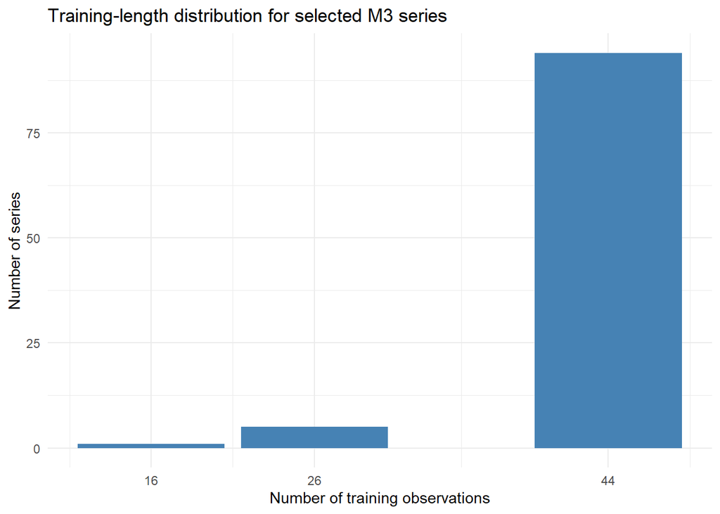

```r
ggplot(train_lengths, aes(x = Train_Length)) +
  geom_bar(fill = "steelblue") +
  scale_x_continuous(breaks = sort(unique(train_lengths$Train_Length))) +
  labs(
    title = "Training-length distribution for selected M3 series",
    x = "Number of training observations",
    y = "Number of series"
  ) +
  theme_minimal()
```

## Exploratory Analysis

Visual inspection of a few random series :

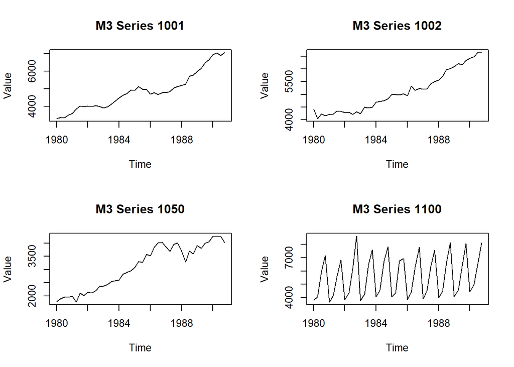

```r
par(mfrow = c(2, 2))

plot(
  M3[[1001]]$x,
  main = "M3 Series 1001",
  ylab = "Value",
  xlab = "Time"
)

plot(
  M3[[1002]]$x,
  main = "M3 Series 1002",
  ylab = "Value",
  xlab = "Time"
)

plot(
  M3[[1050]]$x,
  main = "M3 Series 1050",
  ylab = "Value",
  xlab = "Time"
)

plot(
  M3[[1100]]$x,
  main = "M3 Series 1100",
  ylab = "Value",
  xlab = "Time"
)
```

```r
par(mfrow = c(1, 1))
```

### Seasonality and Trend

We can see that some of the data may have seasonal components while others may not.

```r
is_trended <- array(
  FALSE,
  tsn
)

is_seasonal <- array(
  FALSE,
  tsn
)

for (tsi in tsis) {

  y <- M3[[tsi]]$x

  fit <- ets(y)

  is_trended[tsi - 1000] <-
    fit$components[2] != "N"

  is_seasonal[tsi - 1000] <-
    fit$components[3] != "N"
}

sum(is_trended)
```

```
## [1] 77
```

```r
sum(!is_trended)
```

```
## [1] 23
```

```r
sum(is_seasonal)
```

```
## [1] 25
```

```r
sum(!is_seasonal)
```

```
## [1] 75
```

77 of the 100 series show a trend while 23 do not, and 25 of the 100 series have seasonality while 75 do not.

```r
component_summary <- data.frame(
  Component = c(
    "Trend",
    "No trend",
    "Seasonality",
    "No seasonality",
    "Trend and seasonality",
    "Trend only",
    "Seasonality only",
    "Neither"
  ),

  Number_of_series = c(
    sum(is_trended),
    sum(!is_trended),
    sum(is_seasonal),
    sum(!is_seasonal),
    sum(is_trended & is_seasonal),
    sum(is_trended & !is_seasonal),
    sum(!is_trended & is_seasonal),
    sum(!is_trended & !is_seasonal)
  )
)

component_summary
```

```
##               Component Number_of_series
## 1                 Trend               77
## 2              No trend               23
## 3           Seasonality               25
## 4        No seasonality               75
## 5 Trend and seasonality               22
## 6            Trend only               55
## 7      Seasonality only                3
## 8               Neither               20
```

## Forecasting methods

For forecasting we will use 3 methods namely automatic ETS, automatic ARIMA and a combined model of the 2.

The combined forecast assigns equal weight to ETS and ARIMA because the two models represent different forecasting structures and neither model is assumed to dominate before evaluation.

The benchmark methods used are Naive and Seasonal Naive.

```r
# To be used for logging the non-seasonal and seasonal orders of the ARIMA model
ARorder <- array(0, 5)
MAorder <- array(0, 5)
Differencing <- array(0, 3)

SeasonalARorder <- array(0, 3)
SeasonalMAorder <- array(0, 3)
SeasonalDifferencing <- array(0, 3)

for (tsi in tsis){

  print(tsi)

  y <- M3[[tsi]]$x
  yout <- M3[[tsi]]$xx

  h <- length(yout)

  # Proposed model 1: ETS

  fit_ets <- ets(y)

  fcs_ets <- forecast(
    fit_ets,
    h = h
  )$mean

  # Proposed model 2: ARIMA

  fit_arima <- auto.arima(y)

  fcs_arima <- forecast(
    fit_arima,
    h = h
  )$mean

  # Determine non-seasonal and seasonal orders for ARIMA
  ARorder[fit_arima$arma[1] + 1] <-ARorder[fit_arima$arma[1] + 1] + 1

  MAorder[fit_arima$arma[2] + 1] <-MAorder[fit_arima$arma[2] + 1] + 1

  Differencing[fit_arima$arma[6] + 1] <-Differencing[fit_arima$arma[6] + 1] + 1

  SeasonalARorder[fit_arima$arma[3] + 1] <-SeasonalARorder[fit_arima$arma[3] + 1] + 1

  SeasonalMAorder[fit_arima$arma[4] + 1] <-SeasonalMAorder[fit_arima$arma[4] + 1] + 1

  SeasonalDifferencing[fit_arima$arma[7] + 1] <-SeasonalDifferencing[fit_arima$arma[7] + 1] + 1

  # Proposed model 3: combined ETS-ARIMA

  fcs_combined <- 0.5 * fcs_ets +
                  0.5 * fcs_arima

  # Benchmark 1: naive

  fcs_naive <- naive(
    y,
    h = h
  )$mean

  # Benchmark 2: seasonal naive

  fcs_snaive <- snaive(
    y,
    h = h
  )$mean

  # Seasonal MASE scaling factor

  scale <- mean(abs(diff(y, lag = 4)))

  # Store forecasts in a list

  forecasts <- list(
    fcs_ets,
    fcs_arima,
    fcs_combined,
    fcs_naive,
    fcs_snaive
  )

  # Calculate errors

  for (method in 1:length(Methods)){

    fcs <- forecasts[[method]]

    MASE[tsi - 1000, method] <-
      mean(abs(yout - fcs)) / scale

    sMAPE[tsi - 1000, method] <-
      200 * mean(
        abs(yout - fcs) /
        (abs(yout) + abs(fcs))
      )
  }
}
```

```
## [1] 1001
## [1] 1002
## [1] 1003
## [1] 1004
## [1] 1005
## [1] 1006
## [1] 1007
## [1] 1008
## [1] 1009
## [1] 1010
## [1] 1011
## [1] 1012
## [1] 1013
## [1] 1014
## [1] 1015
```

[output cut: 85 more lines]

ARIMA model non-seasonal orders:

```r
names(ARorder) <- paste0("p=",0:(length(ARorder) - 1))

names(MAorder) <- paste0("q=",0:(length(MAorder) - 1))

names(Differencing) <- paste0("d=",0:(length(Differencing) - 1))

names(SeasonalARorder) <- paste0("P=",0:(length(SeasonalARorder) - 1))

names(SeasonalMAorder) <- paste0("Q=",0:(length(SeasonalMAorder) - 1))

names(SeasonalDifferencing) <- paste0("D=",0:(length(SeasonalDifferencing) - 1))

ARorder
```

```
## p=0 p=1 p=2 p=3 p=4
##  63  24  11   2   0
```

```r
MAorder
```

```
## q=0 q=1 q=2 q=3 q=4
##  73  23   2   2   0
```

```r
Differencing
```

```
## d=0 d=1 d=2
##  13  70  17
```

```r
SeasonalARorder
```

```
## P=0 P=1 P=2
##  86   9   5
```

```r
SeasonalMAorder
```

```
## Q=0 Q=1 Q=2
##  65  33   2
```

```r
SeasonalDifferencing
```

```
## D=0 D=1 D=2
##  75  25   0
```

## Evaluation Measures

MASE and sMAPE were selected because the forecasts are evaluated across 100 quarterly time series with different scales and magnitudes. Both measures are scale-independent, which allows accuracy to be compared more fairly across series than would be possible using unscaled measures such as MAE or RMSE.

MASE compares the forecast error with the error from a seasonal naïve benchmark. Since the data are quarterly, the scaling factor is based on seasonal differences at lag four. This gives MASE a useful interpretation: values below one indicate that the forecasting method outperforms the seasonal benchmark, whereas values above one indicate inferior performance.

sMAPE was selected to complement MASE as percentage-based measure. It evaluates the forecast error relative to the combined size of the actual and forecast values. Lower sMAPE values indicate greater forecast accuracy.

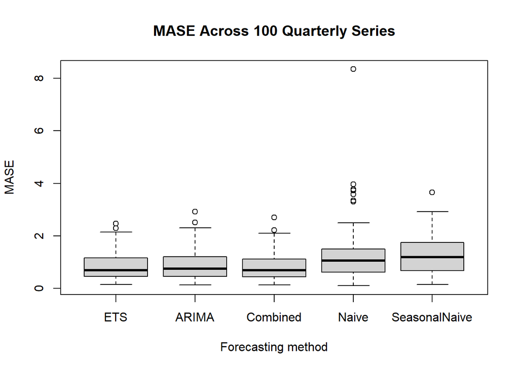

```r
boxplot(
  MASE,
  names = Methods,
  main = "MASE Across 100 Quarterly Series",
  xlab = "Forecasting method",
  ylab = "MASE"
)
```

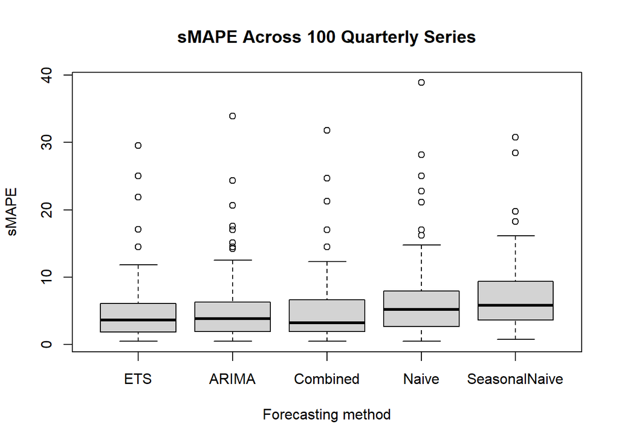

```r
boxplot(
  sMAPE,
  names = Methods,
  main = "sMAPE Across 100 Quarterly Series",
  xlab = "Forecasting method",
  ylab = "sMAPE"
)
```

Bar-plot of errors:

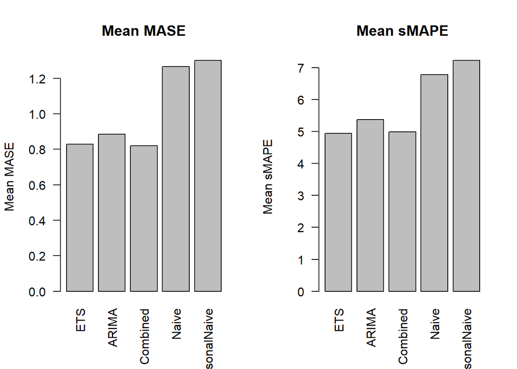

```r
par(mfrow = c(1, 2))

barplot(
  colMeans(MASE, na.rm = TRUE),
  names.arg = Methods,
  main = "Mean MASE",
  ylab = "Mean MASE",
  las = 2
)

barplot(
  colMeans(sMAPE, na.rm = TRUE),
  names.arg = Methods,
  main = "Mean sMAPE",
  ylab = "Mean sMAPE",
  las = 2
)
```

```r
par(mfrow = c(1, 1))
```

Distribution of the number of wins of errors for MASE:

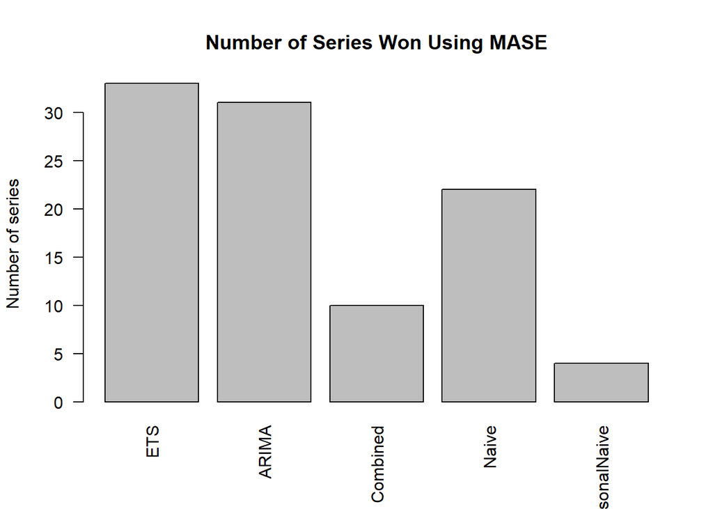

```r
winner_MASE <- apply(
  MASE,
  1,
  which.min
)

winner_MASE <- table(
  factor(
    winner_MASE,
    levels = 1:length(Methods),
    labels = Methods
  )
)

barplot(
  winner_MASE,
  main = "Number of Series Won Using MASE",
  ylab = "Number of series",
  las = 2
)
```

Distribution of the number of wins of errors for sMAPE:

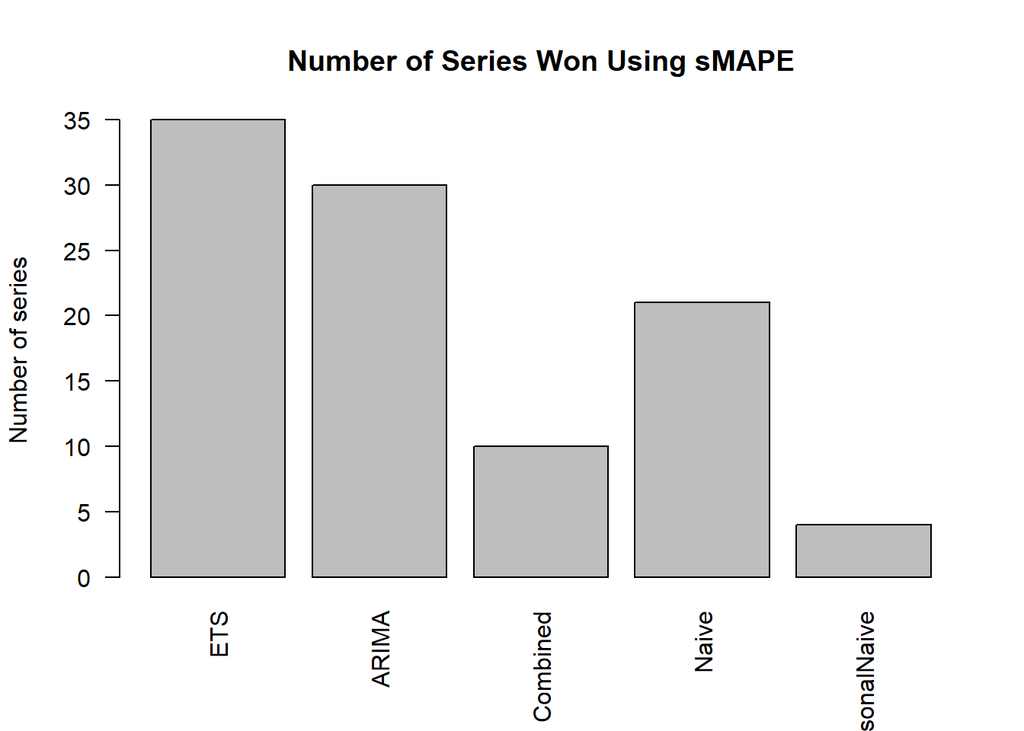

```r
winner_sMAPE <- apply(
  sMAPE,
  1,
  which.min
)

winner_sMAPE <- table(
  factor(
    winner_sMAPE,
    levels = 1:length(Methods),
    labels = Methods
  )
)

barplot(
  winner_sMAPE,
  main = "Number of Series Won Using sMAPE",
  ylab = "Number of series",
  las = 2
)
```

Summary of proposed models

```r
colMeans(
  MASE[, 1:3],
  na.rm = TRUE
)
```

```
##       ETS     ARIMA  Combined
## 0.8283290 0.8859003 0.8207217
```

```r
colMeans(
  sMAPE[, 1:3],
  na.rm = TRUE
)
```

```
##      ETS    ARIMA Combined
## 4.936170 5.370717 4.991216
```

Summary of benchmark models

```r
colMeans(
  MASE[, 4:5],
  na.rm = TRUE
)
```

```
##         Naive SeasonalNaive
##      1.267016      1.301022
```

```r
colMeans(
  sMAPE[, 4:5],
  na.rm = TRUE
)
```

```
##         Naive SeasonalNaive
##      6.784217      7.226438
```

Compare all 5 models

```r
results <- rbind(
  Mean_MASE = colMeans(
    MASE,
    na.rm = TRUE
  ),

  Median_MASE = apply(
    MASE,
    2,
    median,
    na.rm = TRUE
  ),

  Mean_sMAPE = colMeans(
    sMAPE,
    na.rm = TRUE
  ),

  Median_sMAPE = apply(
    sMAPE,
    2,
    median,
    na.rm = TRUE
  )
)

colnames(results) <- Methods

results
```

```
##                    ETS     ARIMA  Combined    Naive SeasonalNaive
## Mean_MASE    0.8283290 0.8859003 0.8207217 1.267016      1.301022
## Median_MASE  0.6901758 0.7452823 0.6837836 1.048280      1.180335
## Mean_sMAPE   4.9361697 5.3707175 4.9912161 6.784217      7.226438
## Median_sMAPE 3.6243707 3.8532041 3.1852516 5.166932      5.822305
```

Winner

```r
best_mean_mase <- names(which.min(results["Mean_MASE", ]))
best_median_mase <- names(which.min(results["Median_MASE", ]))
best_mean_smape <- names(which.min(results["Mean_sMAPE", ]))
best_median_smape <- names(which.min(results["Median_sMAPE", ]))

best_mean_mase
```

```
## [1] "Combined"
```

```r
best_median_mase
```

```
## [1] "Combined"
```

```r
best_mean_smape
```

```
## [1] "ETS"
```

```r
best_median_smape
```

```
## [1] "Combined"
```

```r
results
```

```
##                    ETS     ARIMA  Combined    Naive SeasonalNaive
## Mean_MASE    0.8283290 0.8859003 0.8207217 1.267016      1.301022
## Median_MASE  0.6901758 0.7452823 0.6837836 1.048280      1.180335
## Mean_sMAPE   4.9361697 5.3707175 4.9912161 6.784217      7.226438
## Median_sMAPE 3.6243707 3.8532041 3.1852516 5.166932      5.822305
```

```r
winner_MASE
```

```
##
##           ETS         ARIMA      Combined         Naive SeasonalNaive
##            33            31            10            22             4
```

```r
winner_sMAPE
```

```
##
##           ETS         ARIMA      Combined         Naive SeasonalNaive
##            35            30            10            21             4
```